# *when will i get to canada?*

or: some properties of cumulative distributions

# 1 Introduction

I applied for a study-permit from the Canadian government’s office of immigration on **July 30, 2020**. The processing time estimate is presented as the time it takes for the office to complete **80%** of the applications it has at any given time. This value, which we’ll call $E$, was **11 weeks**/**77 days** when I submitted my application. To estimate when my application will be complete, I briefly discuss how cumulative distributions work, and then propose and use several candidates for the true distribution of processing times to estimate when my application will be done.

# 2 Cumulative Distributions

To estimate the time it will take until my application is processed, its worth considering what the value of $E$ really means. It is a *cumulative* measure of probability, which can have bizarre properties.

To estimate this value, the office must be taking a set of applications they have completed in the past and considering the amount of time it took them to complete each application, $\{t_1, t_2, \dots \}$. These values are all samples from the distribution of processing times, which we’ll call $T$.

We call the probability that the amount of time to process an application is exactly $t$ is the probability-density function (pdf), $\pi(t)$. (For example, the pdf for rolling a dice $\pi_{Dice}(x) = \frac{1}{6}$ for all values of $x = \{1,2,3,4,5,6\}$.

From this, we can get our cumalitive distribution function (cdf), $\Pi(t)$, which gives us the probability that a sample from $T$ is less than $t$. The cdf $\Pi(t)$ is defined as
$$\Pi(t) = \int_{-\infty}^t \pi(u) du$$

We know that $\Pi(\text{77 days}) = 0.8$, and therefore we can place a constraint on the distribution of processing times $\pi(t)$, which is that
$$\Pi(\text{77 days}) = \int_{0}^{77 \ \text{days}} \pi(t) dt = 0.8$$

We can now use this constaint to place restrictions on the shape of the distribution of processing times, $\pi(t)$.

# 3 Processing Times Distributions

Here we propose several potential forms the true distribution of processing times might take on, $\pi(t)$, and use them to estimate when the application will be done.

## 3.1 Gamma Distribution

$$\pi_\Gamma(x) = \frac{\beta ^ \alpha}{\Gamma(\alpha)} x^{\alpha -1} e^{-\beta x}$$

where $\Gamma(\alpha)$ is the Gamma function

$$\Gamma(\alpha) = \int_0^\infty x^{\alpha-1} e^{-x} dx$$

The cdf for the Gamma distribution is also analytically solvable as

$$\Pi(x) = \frac{\gamma(\alpha, \beta x) } {\Gamma(\alpha)}$$
where $\gamma$ is the *incomplete*-Gamma function,

$$\gamma(s,x) = \int_0^x t^{s-1} e^{-t} dt$$

This allows us again to set the constraint

$$\Pi(\text{77 days}) = 0.8 = \frac{\gamma(\alpha, 77 \beta ) } {\Gamma(\alpha)}$$

Here, then, we have one degree of freedom over our parameter $\alpha$, and without any further data, we have no methods by which to estimate it, and must resort testing a variety of values. Example gamma distributions that meet our constraint are shown below

```r
get_beta_under_constraint = function(alpha){
  f = function(b) abs((gammainc(alpha,b)[1]/ gamma(alpha)) - 0.8)
  b = optimize(f, c(0,20))
  return(b$minimum)
}
```

# 4 Estimating When the Application Will Be Done

## 4.1 Fixed $\alpha$

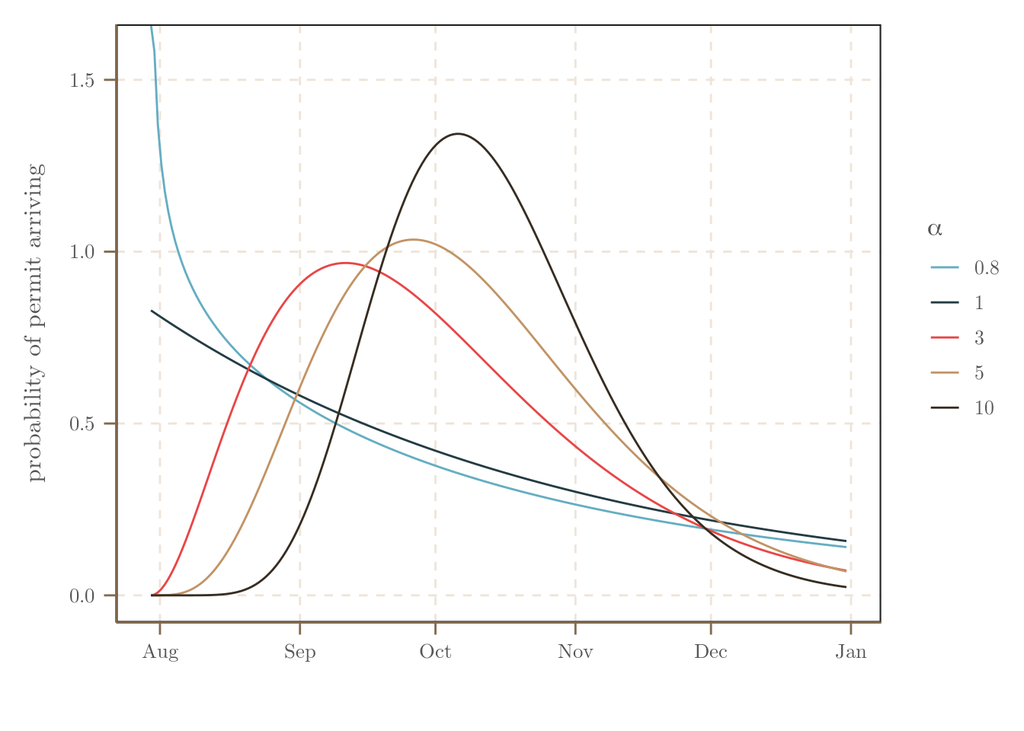

```r
potential_alphas = c(0.8, 1,3, 5, 10)
S_days =77
start_date = "2020-07-30"
df = data.frame(start_date=as.Date(c(start_date))) %>%
  crossing(data.frame(alpha=potential_alphas)) %>%
  mutate(beta=sapply(alpha, get_beta_under_constraint)) %>%
  crossing(data.frame(time_in_unit_of_S = seq(0,2,by=0.01))) %>%
  mutate(arrival_probability = dgamma(time_in_unit_of_S,alpha,beta)) %>%
  mutate(days_since_application=time_in_unit_of_S*S_days) %>%
  mutate(date = as.Date(start_date + days_since_application)) %>%
  mutate(variance = alpha/beta^2)

ggplot(df, aes(date, arrival_probability, color=factor(alpha))) + geom_line() + thm + labs(x='', y='probability of permit arriving', color=TeX('$\\alpha$'))
```

## 4.2 $\alpha$ from priors

If we set priors on $\alpha$, we can then estimate the arrival date.

I’m inclined to believe that the distribution of applications has a fat-tail, many applications a processed smoothly and don’t take long, but a few have many caveats which take a very long time.

Drawing from uniform priors
$$\alpha \sim \text{Uniform}(\alpha_{min}, \alpha_{max})$$

```r
sample_arrival_date = function(alpha){
  beta = get_beta_under_constraint(alpha)
  arrival_time = rgamma(1, alpha, rate=beta)
  return(arrival_time)
}

sample_arrival_distribution_uniform = function(min=0.5, max=5, n_samples =1000) {
  times = rep(0,n_samples)

  for (t in 1:n_samples) {
    alpha = runif(1, min=min, max=max)
    time = sample_arrival_date(alpha)
    times[t] = time
  }

  df = data.frame(min_alpha=c(min), max_alpha=c(max)) %>% crossing(data.frame(arrival_time=times))

  return(df)
}
```

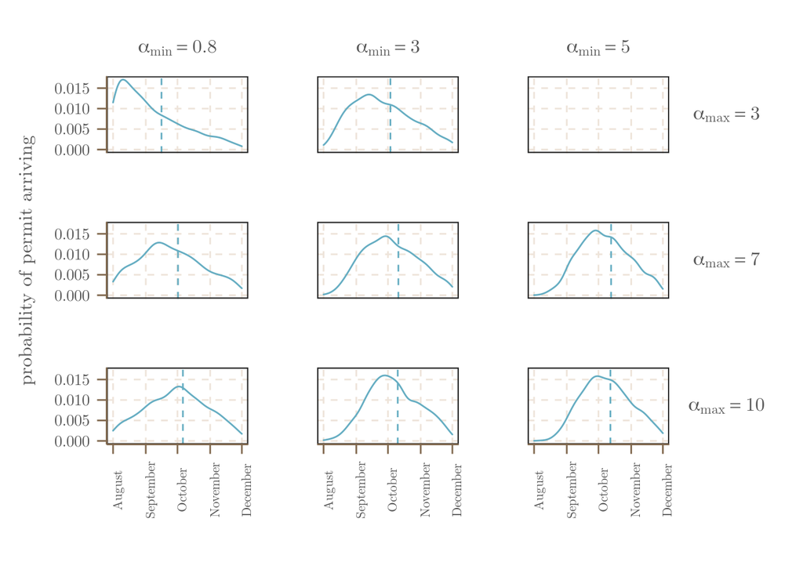

```r
data.frame(min_alpha = c(0.8,3,5)) %>%
  crossing(max_alpha=c(3,7,10)) %>%
    mutate(min_facet = paste('$\\alpha_{min} = ', min_alpha ,'$', sep='')) %>%
  mutate(max_facet = paste('$\\alpha_{max} = ', max_alpha ,'$', sep='')) %>%
  mutate(max_facet = factor(max_facet, levels=c("$\\alpha_{max} = 3$","$\\alpha_{max} = 7$","$\\alpha_{max} = 10$"))) %>%
  group_by(min_alpha, max_alpha) %>%
  filter((min_alpha <= max_alpha) == T) %>%
  do(cbind(., sample_arrival_distribution_uniform(min=.$min_alpha, max=.$max_alpha), by=c("min_alpha", "max_alpha"))) %>%
  mutate(arrival_time_in_days = arrival_time*S_days) %>%
  mutate(mean_arriv_time = as.Date(as.Date(start_date) + mean(arrival_time_in_days))) %>%
  mutate(arrival_date = as.Date(as.Date(start_date) + arrival_time_in_days)) %>%
  ggplot(aes(arrival_date, group=interaction(min_alpha, max_alpha))) +
    geom_density() +
    scale_x_date(limits=c(as.Date("2020-08-01"), as.Date("2020-12-01")), breaks="month", minor_breaks="2 weeks", date_labels = "%B") +
    geom_vline(aes(xintercept=mean_arriv_time), linetype='dashed') +
    facet_grid(vars(max_facet), vars(min_facet),labeller=as_labeller(convert_to_tex_label, label_parsed)) +
    labs(x='', y='probability of permit arriving') +
    thm +
    theme(axis.text.x = element_text(size=8, angle = 90))
```

What then, about the *cumulative* distribution of *arrival time*—that is, given some time $t$, what is the probability that I will have received the notice by that point?

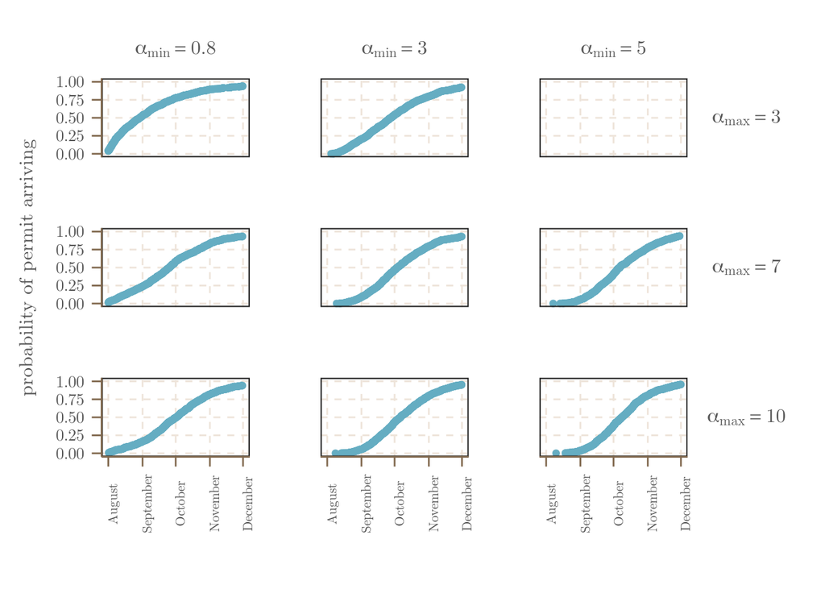

```r
get_cumulative_prob_of_arriv = function(arrival_times){
  ret = rep(0, length(arrival_times))
  i = 1
  for (t in arrival_times){
    ct = 0
    for (t2 in arrival_times){
      if (t < t2){
        ct = ct + 1
      }
    }
    ret[i] = 1.0 - ct/length(arrival_times)
    i = i + 1
  }
  return (ret)
}

data.frame(min_alpha = c(0.8,3,5)) %>%
  crossing(max_alpha=c(3,7,10)) %>%
    mutate(min_facet = paste('$\\alpha_{min} = ', min_alpha ,'$', sep='')) %>%
  mutate(max_facet = paste('$\\alpha_{max} = ', max_alpha ,'$', sep='')) %>%
  mutate(max_facet = factor(max_facet, levels=c("$\\alpha_{max} = 3$","$\\alpha_{max} = 7$","$\\alpha_{max} = 10$"))) %>%
  group_by(min_alpha, max_alpha) %>%
  filter((min_alpha <= max_alpha) == T) %>%
  do(cbind(., sample_arrival_distribution_uniform(min=.$min_alpha, max=.$max_alpha), by=c("min_alpha", "max_alpha"))) %>%
  mutate(arrival_time_in_days = arrival_time*S_days) %>%
  mutate(arrival_date = as.Date(as.Date(start_date) + arrival_time_in_days)) %>%
  mutate(cumulative_prob_of_arriv = get_cumulative_prob_of_arriv(arrival_time_in_days) ) %>%
    ggplot(aes(arrival_date, cumulative_prob_of_arriv, group=interaction(min_alpha, max_alpha))) +
    geom_point() +
    scale_x_date(limits=c(as.Date("2020-08-01"), as.Date("2020-12-01")), breaks="month", minor_breaks="2 weeks", date_labels = "%B") +    facet_grid(vars(max_facet), vars(min_facet),labeller=as_labeller(convert_to_tex_label, label_parsed)) +
    labs(x='', y='probability of permit arriving') +
    thm +
    theme(axis.text.x = element_text(size=8, angle = 90))
```